# EFA: New scale

This report narrates the process of factor analizing the proposed scale

# Introduction

The purpose of this research was to develop a new scale for measuring subjective wellbing of people condending with substance use disorder using a mobile device. Participants were 427 students of Indiana State University.

# Overview

By comparing various rotations and considering interpretive qualities of the solutions, we have decided to use orthogonal bifactor rotation, as the one that offers the greatest interpretability.

## Analysis Steps

### 1.Scree

Scree plot is plotted and top eigen values are displayed

### 2.MAP

`psych::nfactors` call is applied, producing Very Simple Structure, Velicer’s MAP, and other criteria to determine the appropriate number of factors. See [documentation](http://www.personality-project.org/r/html/VSS.html)

### 3.Parallel Analysis

`psych::fa.parallel` call is applied, comparing the number of factors in the correlation matrix to random “parallel” matrices. For details, see [documentation](https://www.rdocumentation.org/packages/psych/versions/1.6.9/topics/fa.parallel?)

### 4.Fit

`psych::fa` call is applied to conduct maximum likelihood factor analysis (`fm="ml"`) in order to obtain the chi-square of the proposed models, which incrementally increase the number of retained factors. CFI and TLI indices are then computed, following the formulae:

```
  CFI = ((chisq_null-df_null) - (chisq-df))/(chisq_null-df_null)
  TLI = ((chisq_null/df_null) - (chisq/df))/((chisq_null/df_null)-1)
```

For details on `psych::fa` see [documentation](https://www.rdocumentation.org/packages/psych/versions/1.6.9/topics/fa)

### 5.RMSEA

RMSEA diagnostic is conducted using [Advanced Factor Function](http://statpower.net/Content/312/R%20Stuff/AdvancedFactorFunctions.txt) by James Steiger. The routine relies on the maxim likelihood factor analysis conducted by `stats::factanal` call. For details on the latter see [here](https://stat.ethz.ch/R-manual/R-devel/library/stats/html/factanal.html)

### 6.Estimate

Using [Advanced Factor Function](http://statpower.net/Content/312/R%20Stuff/AdvancedFactorFunctions.txt) by James Steiger, we conduct maximum likelihood factor analysis, by obtaining the unrotated solution from `stats::factanal` call and then rotating solution using gradient projection algorithms (Bernaards & Jennrich, 2005).

### 7.Confirm

Applying “Exploratory-Confirmatory” procedure described by [Joreskog(1978)](https://scholar.google.ca/scholar?q=Structural+analysis+of+covariance+and+correlation+matrices&btnG=&hl=en&as_sdt=0%2C33), we find the largest loading for each column of the factor pattern, then constrain all the other loadings in that row to be zero, and fit the resulting model as a confirmatory factor model. Given that we chose the orthogonal bifactor solution, we permit the the cross-loadings between general factor and subfactors.

# EFA

We create a correlation matrix using all items on the administered scale and conduct eigen diagnostics:

## Scree

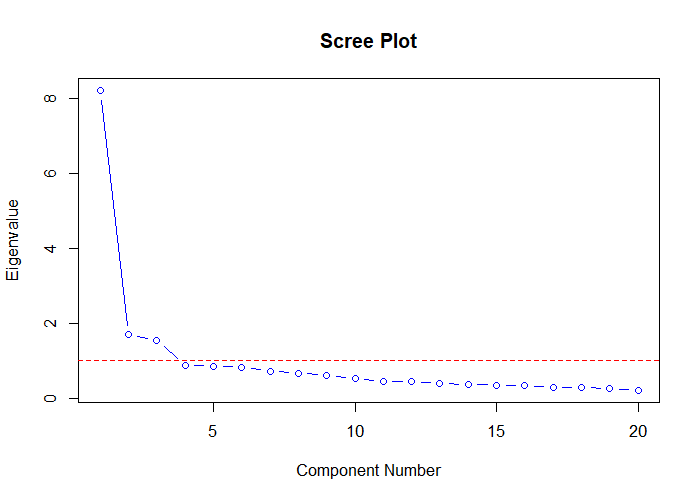

```
   eigen     value
1      1 8.2120510
2      2 1.6938274
3      3 1.5492364
4      4 0.8865132
5      5 0.8534162
6      6 0.8341441
7      7 0.7270440
8      8 0.6757051
9      9 0.6091630
10    10 0.5387882
11    11 0.4550178
12    12 0.4447041
13    13 0.3993914
14    14 0.3738538
15    15 0.3482113
```

Scree plot is somewhat ambiguious, suggesting a solution involving up to 3 factors, following the Keiser rule (eigenvalue > 1).

## MAP

`psych::nfactors` call is applied, producing Very Simple Structure, Velicer’s MAP, and other criteria to determine the appropriate number of factors. See [documentation](http://www.personality-project.org/r/html/VSS.html)

The solution again suggests that no more than 3 meaningful factors can be extracted from the correlation structure.

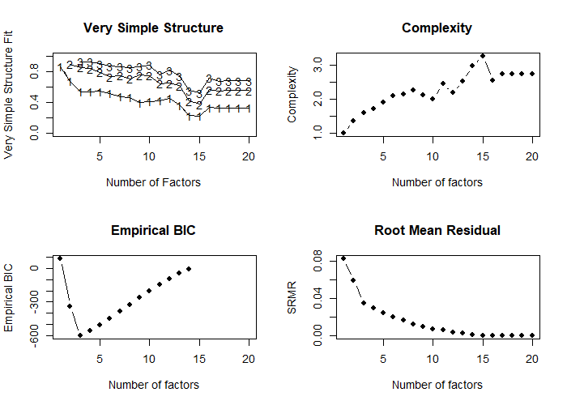

```
Number of factors
Call: vss(x = x, n = n, rotate = rotate, diagonal = diagonal, fm = fm,
    n.obs = n.obs, plot = FALSE, title = title, use = use, cor = cor)
VSS complexity 1 achieves a maximimum of 0.86  with  1  factors
VSS complexity 2 achieves a maximimum of 0.9  with  2  factors
The Velicer MAP achieves a minimum of 0.02  with  3  factors
Empirical BIC achieves a minimum of  -603.72  with  3  factors
Sample Size adjusted BIC achieves a minimum of  -87.25  with  8  factors

Statistics by number of factors
   vss1 vss2   map dof   chisq     prob sqresid  fit RMSEA    BIC SABIC complex  eChisq    SRMR eCRMS   eBIC
1  0.86 0.00 0.021 170 1.1e+03 5.2e-135    10.7 0.86 0.113   65.8 605.3     1.0 1.1e+03 8.3e-02 0.088   88.2
2  0.67 0.90 0.020 151 6.6e+02  1.4e-65     8.0 0.90 0.089 -249.6 229.6     1.4 5.8e+02 6.0e-02 0.067 -337.9
3  0.54 0.85 0.017 133 3.9e+02  2.1e-26     5.9 0.92 0.067 -420.1   2.0     1.6 2.0e+02 3.5e-02 0.042 -603.7
4  0.54 0.84 0.021 116 2.9e+02  1.1e-16     5.3 0.93 0.059 -414.1 -46.0     1.7 1.4e+02 3.0e-02 0.038 -558.1
5  0.54 0.79 0.027 100 2.3e+02  7.0e-12     4.7 0.94 0.055 -378.6 -61.2     1.9 1.0e+02 2.5e-02 0.034 -505.1
6  0.52 0.73 0.033  85 1.7e+02  3.4e-07     4.3 0.95 0.047 -348.6 -78.9     2.1 6.6e+01 2.0e-02 0.030 -449.1
7  0.48 0.75 0.041  71 1.2e+02  8.4e-05     3.8 0.95 0.042 -305.2 -79.9     2.1 4.6e+01 1.7e-02 0.027 -384.5
8  0.46 0.71 0.049  58 8.0e+01  2.9e-02     3.3 0.96 0.030 -271.3 -87.3     2.3 2.6e+01 1.3e-02 0.023 -325.7
9  0.40 0.75 0.059  46 5.0e+01  3.1e-01     2.9 0.96 0.014 -228.5 -82.5     2.1 1.7e+01 1.0e-02 0.021 -261.8
10 0.41 0.75 0.066  35 3.3e+01  5.7e-01     2.5 0.97 0.000 -179.1 -68.1     2.0 8.9e+00 7.4e-03 0.017 -203.1
11 0.42 0.64 0.081  25 2.3e+01  6.0e-01     2.8 0.96 0.000 -128.7 -49.4     2.5 6.0e+00 6.1e-03 0.017 -145.5
12 0.46 0.65 0.094  16 1.3e+01  6.8e-01     2.1 0.97 0.000  -84.0 -33.2     2.2 2.8e+00 4.2e-03 0.014  -94.1
13 0.37 0.62 0.116   8 7.1e+00  5.3e-01     2.3 0.97 0.000  -41.4 -16.0     2.5 1.5e+00 3.0e-03 0.015  -47.0
14 0.23 0.42 0.136   1 1.2e+00  2.8e-01     2.3 0.97 0.019   -4.9  -1.7     3.0 2.1e-01 1.1e-03 0.016   -5.8
15 0.23 0.38 0.177  -5 2.0e-04       NA     2.1 0.97    NA     NA    NA     3.3 3.2e-05 1.4e-05    NA     NA
16 0.34 0.56 0.245 -10 1.1e-05       NA     2.0 0.97    NA     NA    NA     2.6 1.7e-06 3.2e-06    NA     NA
17 0.33 0.55 0.369 -14 4.3e-08       NA     2.1 0.97    NA     NA    NA     2.7 7.7e-09 2.2e-07    NA     NA
18 0.33 0.56 0.553 -17 1.9e-08       NA     2.1 0.97    NA     NA    NA     2.7 3.3e-09 1.4e-07    NA     NA
19 0.33 0.56 1.000 -19 4.4e-10       NA     2.1 0.97    NA     NA    NA     2.7 8.2e-11 2.2e-08    NA     NA
20 0.33 0.56    NA -20 4.4e-10       NA     2.1 0.97    NA     NA    NA     2.7 8.2e-11 2.2e-08    NA     NA
```

## Parallel

`psych::fa.parallel` call is applied, comparing the number of factors in the correlation matrix to random “parallel” matrices. For details, see [documentation](https://www.rdocumentation.org/packages/psych/versions/1.6.9/topics/fa.parallel?)

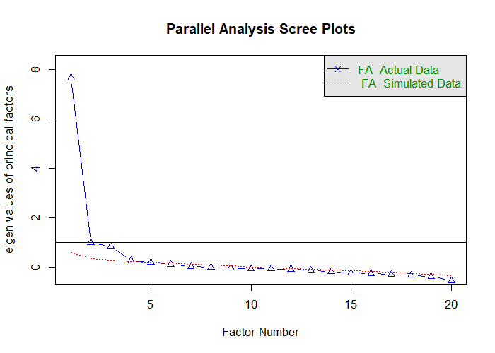

```
Parallel analysis suggests that the number of factors =  4  and the number of components =  NA
```

```
   observed_eigens simulated_eigens
1      7.655685295       0.61044984
2      0.994542517       0.34685612
3      0.844239726       0.29598141
4      0.269632660       0.23974758
5      0.199970175       0.20371859
6      0.129517289       0.16847548
7      0.039944804       0.12398564
8     -0.006467331       0.09037350
9     -0.026975661       0.06092811
10    -0.052193362       0.01959554
11    -0.060142500      -0.00938798
12    -0.069033568      -0.03984756
13    -0.119911700      -0.06892370
14    -0.176364116      -0.09745562
15    -0.222915845      -0.13561839
```

## Fit

`psych::fa` call is applied to conduct maximum likelihood factor analysls (`fm="ml"`) in order to obtain the chi-square of the proposed models, which incrementally increase the number of retained factors. CFI and TLI indices are then computed from the produced criteria. For details on `psych::fa` see [documentation](https://www.rdocumentation.org/packages/psych/versions/1.6.9/topics/fa)

```
  n_factors chisq_null df_null      chisq  df       CFI       TLI
1         1   4263.511     190 1117.88350 170 0.7673055 0.7399297
2         2   4263.511     190  576.66302 151 0.8955046 0.8685158
3         3   4263.511     190  201.83722 133 0.9831013 0.9758589
4         4   4263.511     190  144.50271 116 0.9930029 0.9885393
5         5   4263.511     190  100.53314 100 0.9998691 0.9997513
6         6   4263.511     190   65.77164  85 1.0047203 1.0105513
```

## RMSEA

RMSEA diagnostic is conducted using [Advanced Factor Function](http://statpower.net/Content/312/R%20Stuff/AdvancedFactorFunctions.txt) by James Steiger. The routine relies on the maxim likelihood factor analysis conducted by `stats::factanal` call. For details on the latter see [here](https://stat.ethz.ch/R-manual/R-devel/library/stats/html/factanal.html)

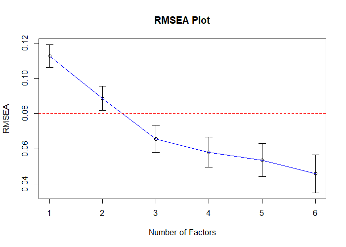

```
     Factors Cum.Eigen Chi-Square  Df      p.value   RMSEA.Pt   RMSEA.Lo   RMSEA.Hi
[1,]       1  8.212051  1090.4368 170 0.000000e+00 0.11273733 0.10639932 0.11917319
[2,]       2  9.905878   655.9242 151 0.000000e+00 0.08859716 0.08170447 0.09560747
[3,]       3 11.455115   376.4958 133 0.000000e+00 0.06555641 0.05781148 0.07340431
[4,]       4 12.341628   282.2465 116 6.661338e-16 0.05800193 0.04943997 0.06663338
[5,]       5 13.195044   221.9364 100 3.058820e-11 0.05350100 0.04403827 0.06298407
[6,]       6 14.029188   161.2841  85 1.170769e-06 0.04589894 0.03496809 0.05662521
```

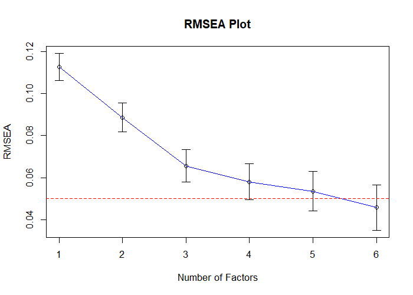

```
     Factors Cum.Eigen Chi-Square  Df      p.value   RMSEA.Pt   RMSEA.Lo   RMSEA.Hi
[1,]       1  8.212051  1090.4368 170 0.000000e+00 0.11273733 0.10639932 0.11917319
[2,]       2  9.905878   655.9242 151 0.000000e+00 0.08859716 0.08170447 0.09560747
[3,]       3 11.455115   376.4958 133 0.000000e+00 0.06555641 0.05781148 0.07340431
[4,]       4 12.341628   282.2465 116 6.661338e-16 0.05800193 0.04943997 0.06663338
[5,]       5 13.195044   221.9364 100 3.058820e-11 0.05350100 0.04403827 0.06298407
[6,]       6 14.029188   161.2841  85 1.170769e-06 0.04589894 0.03496809 0.05662521
```

## Estimate

Using [Advanced Factor Function](http://statpower.net/Content/312/R%20Stuff/AdvancedFactorFunctions.txt) by James Steiger, we conduct maximum likelihood factor analysis, by obtaining the unrotated solution from `stats::factanal` call and then rotating solution using gradient projection algorithms (Bernaards & Jennrich, 2005).

```
This will take a moment..........exiting
```

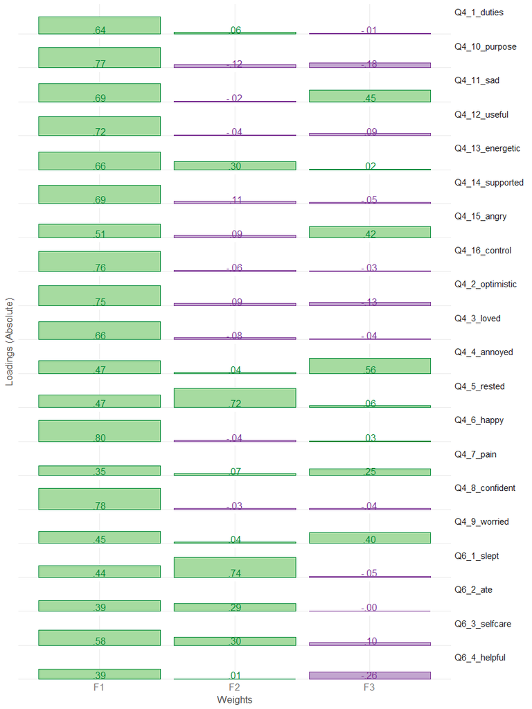

[output not shown]

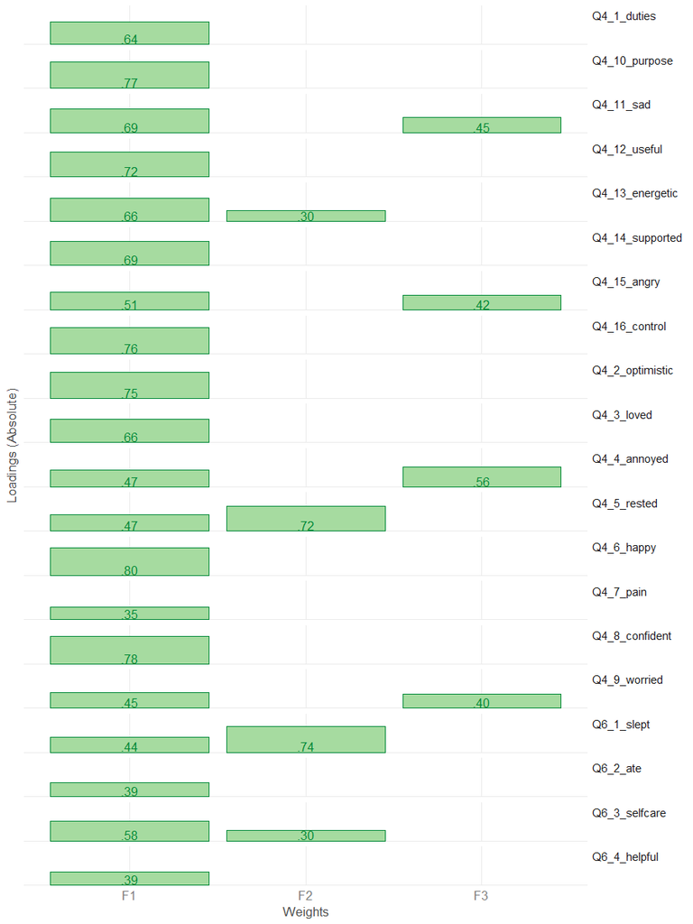

## Confirm

Applying “Exploratory-Confirmatory” procedure described by [Joreskog(1978)](https://scholar.google.ca/scholar?q=Structural+analysis+of+covariance+and+correlation+matrices&btnG=&hl=en&as_sdt=0%2C33), we find the largest loading for each column of the factor pattern, then constrain all the other loadings in that row to be zero, and fit the resulting model as a confirmatory factor model. Given that we chose the orthogonal bifactor solution, we permit the the cross-loadings between general factor and subfactors.

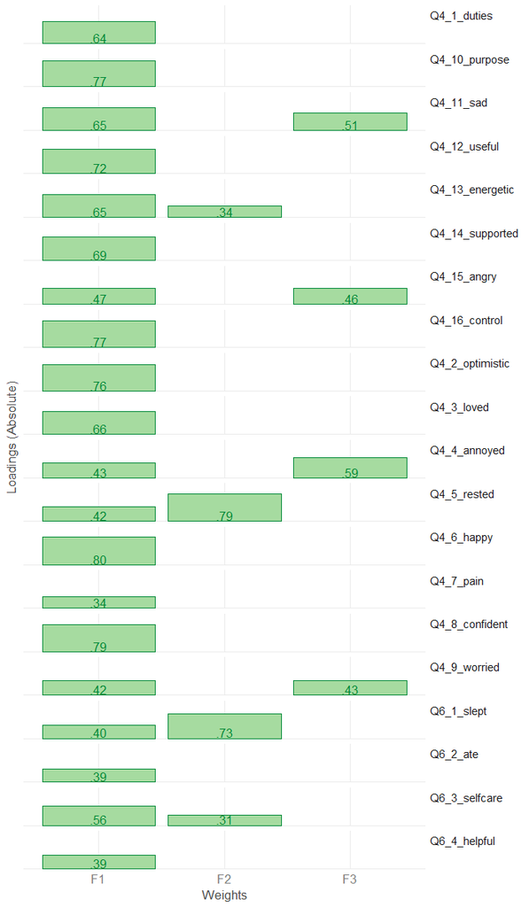

```
Model Chiquare =  521.5535  | df model =  162  | df null =  190
Goodness-of-fit index =  0.8866976
Adjusted Goodness-of-fit index =  0.8531266
RMSEA index =  .0722           90% CI: (.065,.079)
Comparitive Fit Index (CFI = 0.9133589
Tucker Lewis Index (TLI/NNFI) =  0.8983839
Akaike Information Criterion (AIC) = 617.5535
Bayesian Information Criterion (BIC) = -459.6456
```

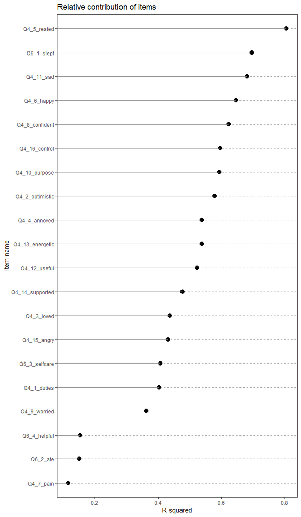

# Rotations

## Varimax

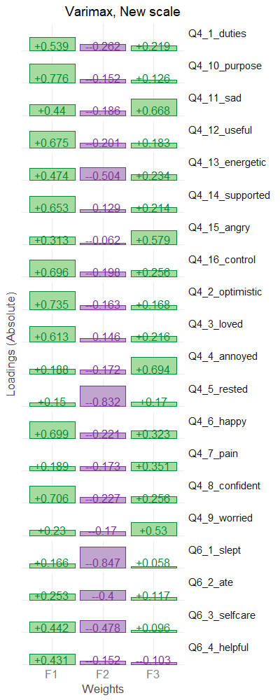

## geominT

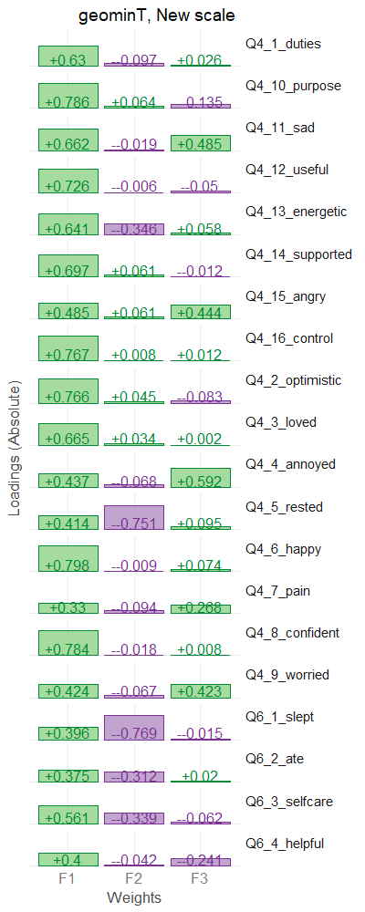

## bifactorT

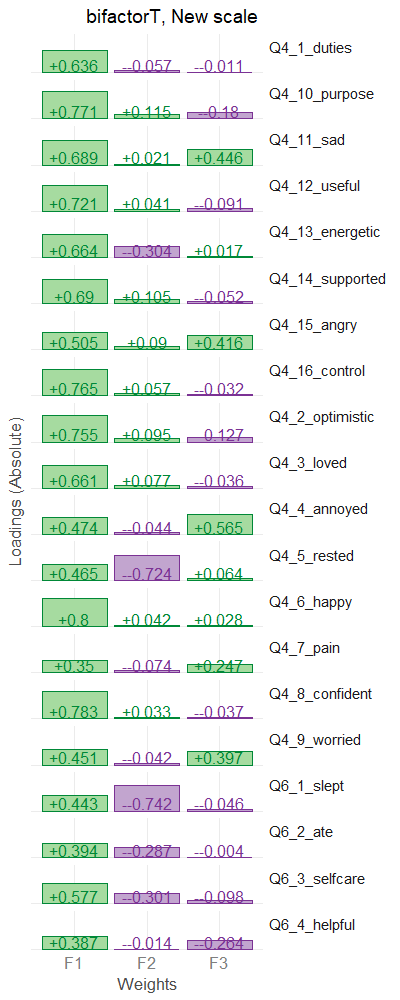

## quartimax

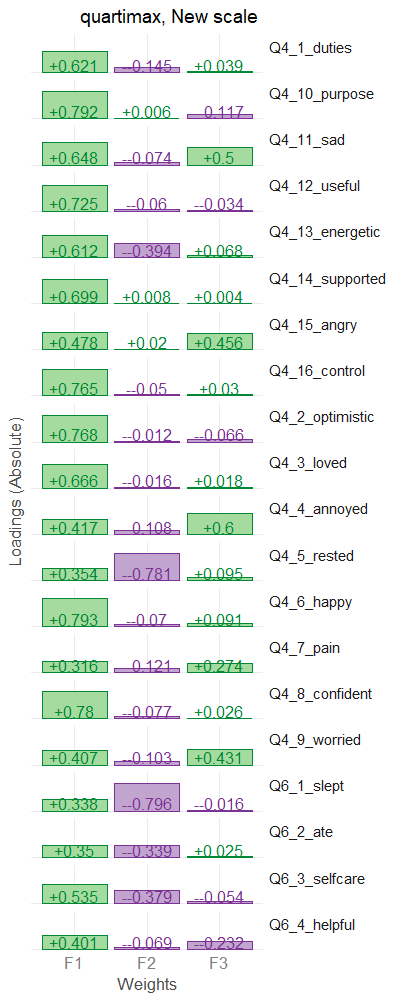

## oblimin

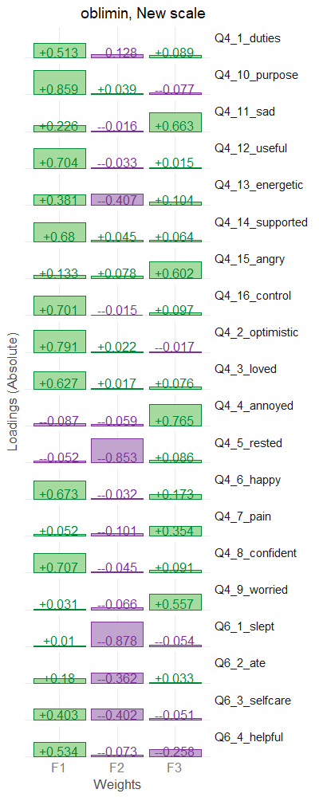

## geominQ

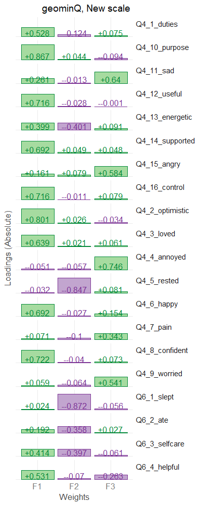

## bifactorQ

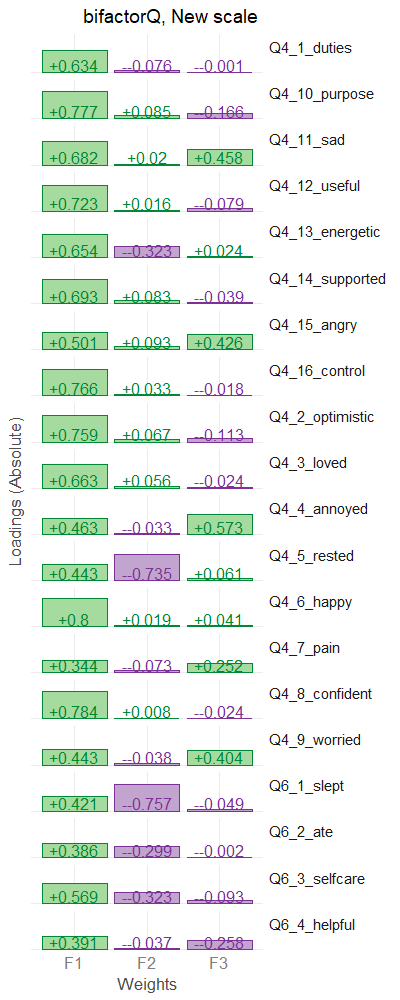

# Correlations

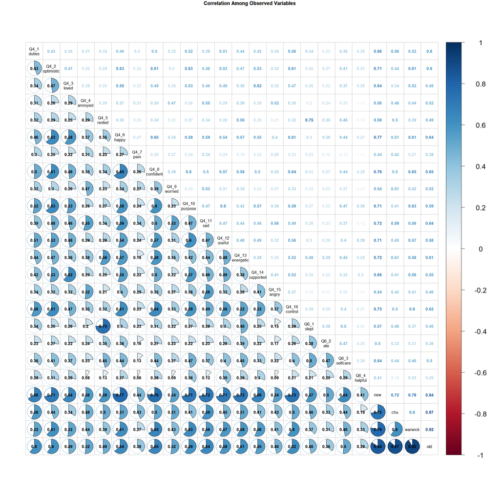

# Decisions

What items should be included into the daily questionnaire?

Guidelines for preference:  
- High item-total correlation to the new scale  
- High item-total correlation to the CHU and Warwick scales  
- Items should cover all factors that seem to be present (3)  
- Items with more pronounced weights onto a single factore should be preferred

7. To represent social facet, we chose `Q4_14` (*Today I feel supported*) over `Q4_3` (*Today I feel loved*), because the former had higher loading, and higher item-total correlations.

# Chosen items

- `Q4_6` (*Today I feel happy*)
- `Q4_8` (*Today I feel confident*)
- `Q4_10` (*Today I feel that my life has a purpose*)
- `Q4_14` (*Today I feel supported*)
- `Q6_3` (*Today I took good care of myself*) - SELFCARE subfactor
- `Q4_5`(*Today I feel rested*) - SELFCARE subfactor
- `Q4_4` (*Today I feel annoyed/irritable*) - DISTRESS subfactor